# Behavior Pilot

Wanjia Guo

9/29/2021

## n = 42

# Prescan analysis

Participant were instructed to answer the expected destination for 3 times during the route: once at Same, once at Overlapping, and once at non-overlapping. They also indicated their confidence towards the choice (sure vs. unsure).

*excluding subject 25 with 0 accuracy (didn’t answer any questions).* *Should we also exclude subjects with around chance level accuracy?*

| sub | m |
| --- | --- |
| 19 | 0.4583333 |
| 37 | 0.5000000 |
| 12 | 0.5416667 |
| 17 | 0.5416667 |
| 41 | 0.5416667 |
| 36 | 0.5833333 |

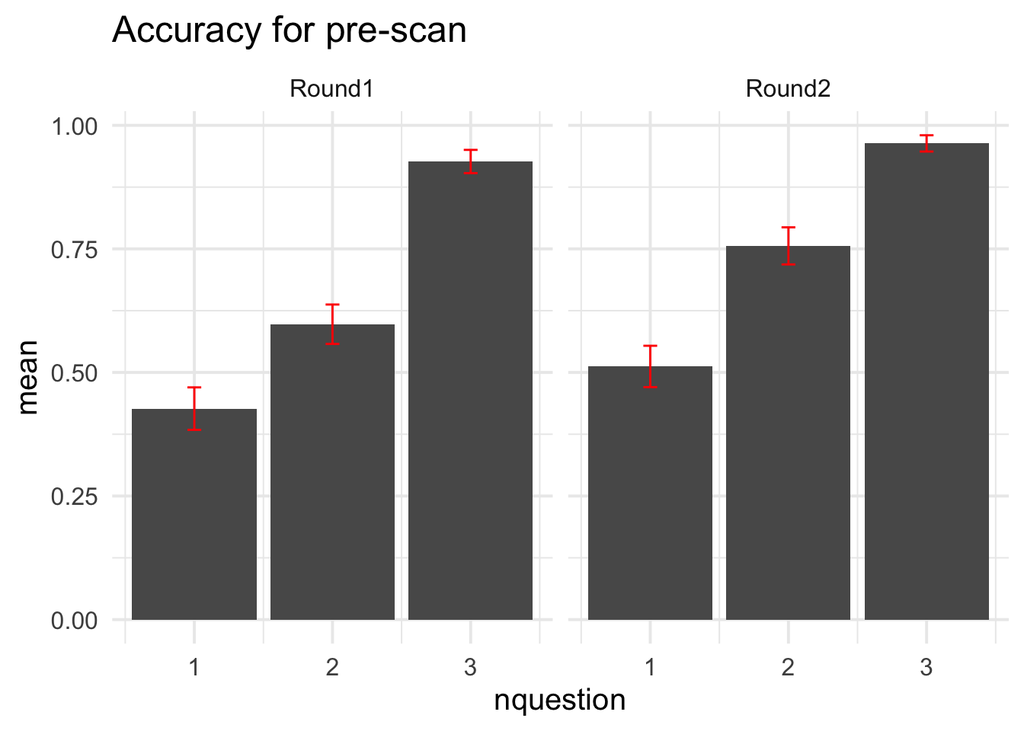

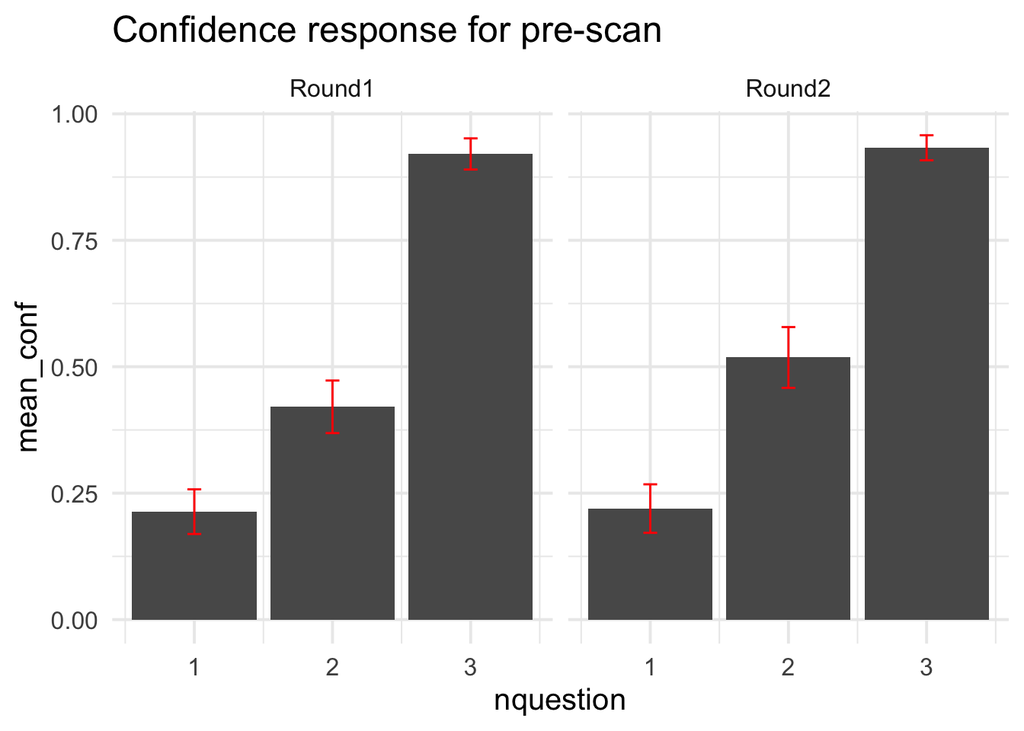

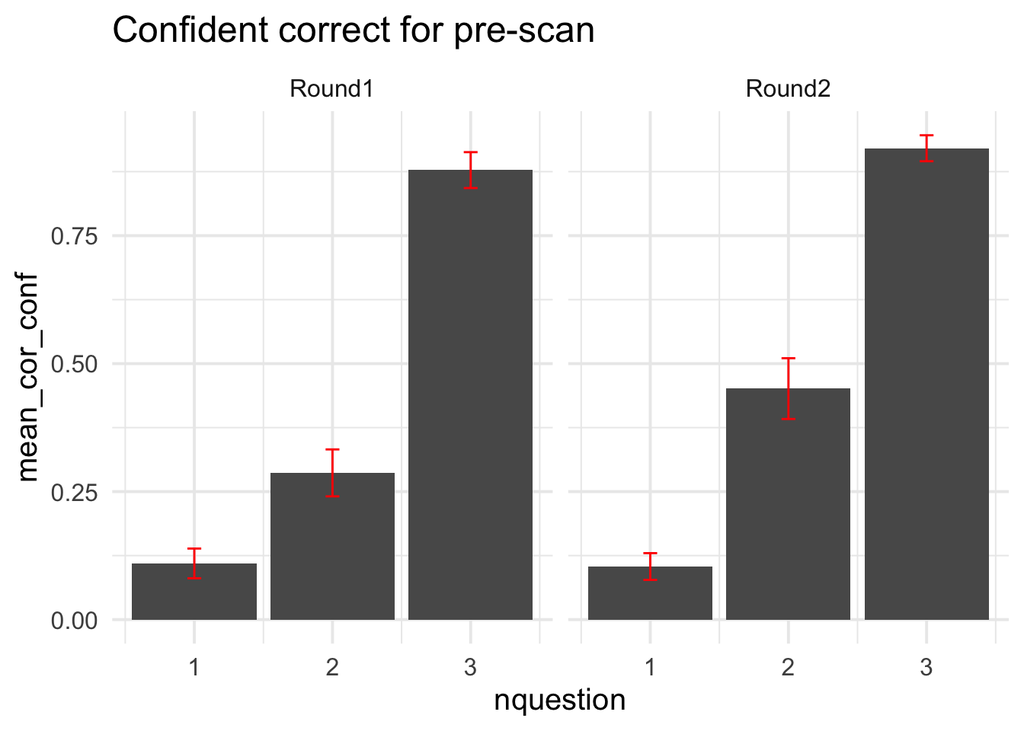

ANVOA for Accuracy:

```
## $ANOVA
##            Effect DFn DFd           F            p p<.05         ges
## 1           round   1  40   8.7329757 5.217202e-03     * 0.088476334
## 2       nquestion   1  40 193.9123506 6.265386e-17     * 0.626097695
## 3 round:nquestion   1  40   0.8387942 3.652306e-01       0.004384362
```

ANVOA for Confidence:

```
## $ANOVA
##            Effect DFn DFd            F            p p<.05          ges
## 1           round   1  40   2.17142857 1.484223e-01       1.453477e-02
## 2       nquestion   1  40 203.02543007 2.906678e-17     * 7.688970e-01
## 3 round:nquestion   1  40   0.03367003 8.553375e-01       6.128077e-05
```

ANVOA for high confidence accuracy:

```
## $ANOVA
##            Effect DFn DFd          F            p p<.05         ges
## 1           round   1  40   6.540541 1.444044e-02     * 0.056816403
## 2       nquestion   1  40 487.734488 5.097511e-24     * 0.848691809
## 3 round:nquestion   1  40   1.237911 2.725161e-01       0.005282271
```

t-test for mean (overlapping segment):

```
##
##  Paired t-test
##
## data:  sub_plot %>% filter(round == 1 & nquestion == 1) %>% .$m and sub_plot %>% filter(round == 2 & nquestion == 1) %>% .$m
## t = -1.7123, df = 40, p-value = 0.09459
## alternative hypothesis: true difference in means is not equal to 0
## 95 percent confidence interval:
##  -0.18612614  0.01539443
## sample estimates:
## mean of the differences
##             -0.08536585
```

```
##
##  Paired t-test
##
## data:  sub_plot %>% filter(round == 1 & nquestion == 2) %>% .$m and sub_plot %>% filter(round == 2 & nquestion == 2) %>% .$m
## t = -3.0368, df = 40, p-value = 0.004195
## alternative hypothesis: true difference in means is not equal to 0
## 95 percent confidence interval:
##  -0.26404586 -0.05302731
## sample estimates:
## mean of the differences
##              -0.1585366
```

```
##
##  Paired t-test
##
## data:  sub_plot %>% filter(round == 1 & nquestion == 3) %>% .$m and sub_plot %>% filter(round == 2 & nquestion == 3) %>% .$m
## t = -1.3553, df = 40, p-value = 0.1829
## alternative hypothesis: true difference in means is not equal to 0
## 95 percent confidence interval:
##  -0.09114440  0.01797367
## sample estimates:
## mean of the differences
##             -0.03658537
```

t-test for confidence (overlapping segment):

```
##
##  Paired t-test
##
## data:  sub_plot %>% filter(round == 1 & nquestion == 1) %>% .$conf and sub_plot %>% filter(round == 2 & nquestion == 1) %>% .$conf
## t = -0.19764, df = 40, p-value = 0.8443
## alternative hypothesis: true difference in means is not equal to 0
## 95 percent confidence interval:
##  -0.06845075  0.05625562
## sample estimates:
## mean of the differences
##            -0.006097561
```

```
##
##  Paired t-test
##
## data:  sub_plot %>% filter(round == 1 & nquestion == 2) %>% .$conf and sub_plot %>% filter(round == 2 & nquestion == 2) %>% .$conf
## t = -2.1967, df = 40, p-value = 0.0339
## alternative hypothesis: true difference in means is not equal to 0
## 95 percent confidence interval:
##  -0.187320669 -0.007801282
## sample estimates:
## mean of the differences
##             -0.09756098
```

```
##
##  Paired t-test
##
## data:  sub_plot %>% filter(round == 1 & nquestion == 3) %>% .$conf and sub_plot %>% filter(round == 2 & nquestion == 3) %>% .$conf
## t = -0.38815, df = 40, p-value = 0.7
## alternative hypothesis: true difference in means is not equal to 0
## 95 percent confidence interval:
##  -0.07569471  0.05130447
## sample estimates:
## mean of the differences
##             -0.01219512
```

t-test for high confidence accuracy (overlapping segment):

```
##
##  Paired t-test
##
## data:  sub_plot %>% filter(round == 1 & nquestion == 1) %>% .$cor_conf and sub_plot %>% filter(round == 2 & nquestion == 1) %>% .$cor_conf
## t = 0.19017, df = 40, p-value = 0.8501
## alternative hypothesis: true difference in means is not equal to 0
## 95 percent confidence interval:
##  -0.05870411  0.07089924
## sample estimates:
## mean of the differences
##             0.006097561
```

```
##
##  Paired t-test
##
## data:  sub_plot %>% filter(round == 1 & nquestion == 2) %>% .$cor_conf and sub_plot %>% filter(round == 2 & nquestion == 2) %>% .$cor_conf
## t = -3.5889, df = 40, p-value = 0.0008964
## alternative hypothesis: true difference in means is not equal to 0
## 95 percent confidence interval:
##  -0.25734848 -0.07191981
## sample estimates:
## mean of the differences
##              -0.1646341
```

```
##
##  Paired t-test
##
## data:  sub_plot %>% filter(round == 1 & nquestion == 3) %>% .$cor_conf and sub_plot %>% filter(round == 2 & nquestion == 3) %>% .$cor_conf
## t = -1.1555, df = 40, p-value = 0.2547
## alternative hypothesis: true difference in means is not equal to 0
## 95 percent confidence interval:
##  -0.11734013  0.03197427
## sample estimates:
## mean of the differences
##             -0.04268293
```

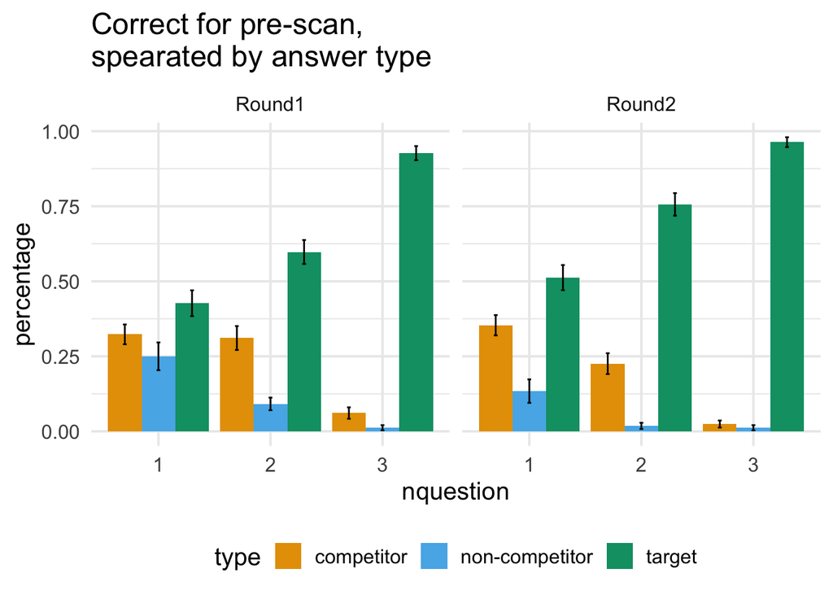

# Scan analysis

### Quality check

Number of trials with no answer across all participant is 212

Table with top5 participants with most missing data –> Excluding subject 12, subject 16, subject 23 (based on the pre-scan), and subject 25 (respond at 1 for all pictures)

| sub | n |
| --- | --- |
| 16 | 69 |
| 23 | 40 |
| 25 | 26 |
| 12 | 24 |
| 22 | 10 |
| 35 | 9 |

| sub | m |
| --- | --- |
| 41 | 0.5384615 |
| 21 | 0.5638298 |
| 32 | 0.6170213 |
| 22 | 0.6976744 |
| 19 | 0.7717391 |
| 11 | 0.8229167 |

Number of total responses

```
## [1] 3595
```

Number of responses of 1 at image 1 with a later response:

```
## [1] 40
```

```
## [1] 3595
```

Number of responses with more than 1 response:

```
## # A tibble: 2 × 2
##   other_TF     n
##      <dbl> <int>
## 1        0   107
## 2        1  3488
```

For the following figure, the index is the picture when participant pressed button to indicate they are SURE of the destination. One distribution is drawn for each destination, colored by different participant. (1-25: Same; 26-75: Overlapping; 76-100: Non-overlapping).

It seems like within each subject, the response is quite consistent for where or when they pressed the button.

*Participant11: pressing ‘6’ prior to picture 25 for 52 times out of 96 times! Probably should also be excluded?*

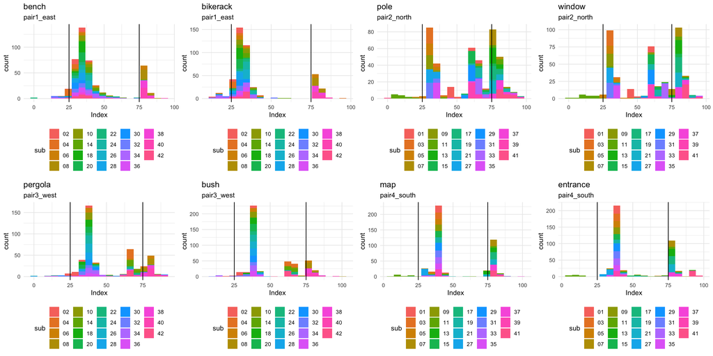

*I also found some subjects with response at picture 1, and later we received another response. In that case, maybe we should use the later response instead?*

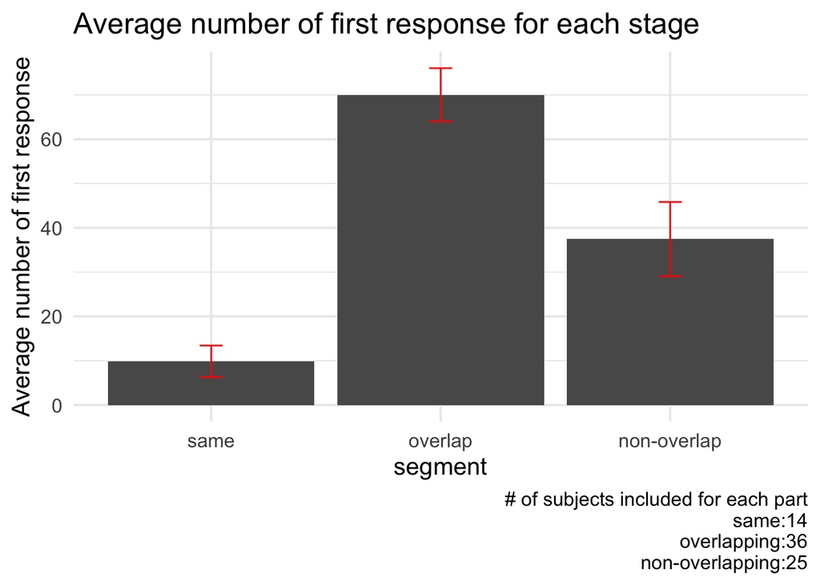

### Correct vs. Incorrect

Most subjects have very little incorrect trials and there doesnt seem to be a difference in the timing when they pressed the button between the correct vs. incorrect.

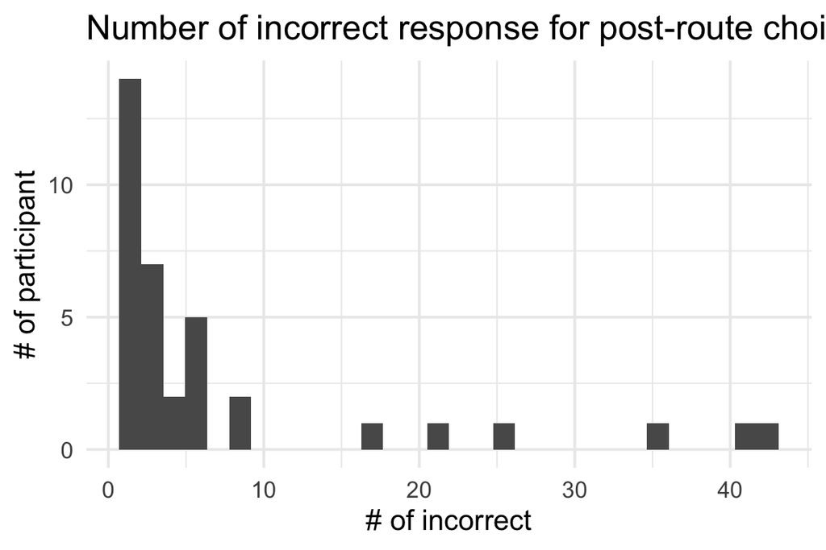

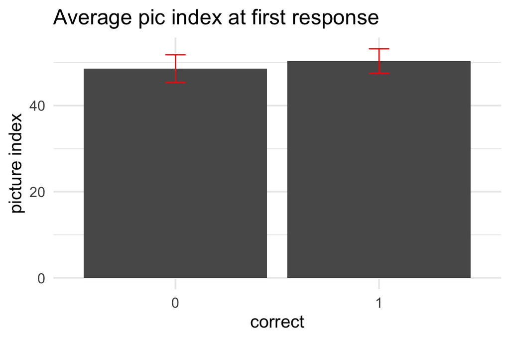

### Valid vs. Invalid

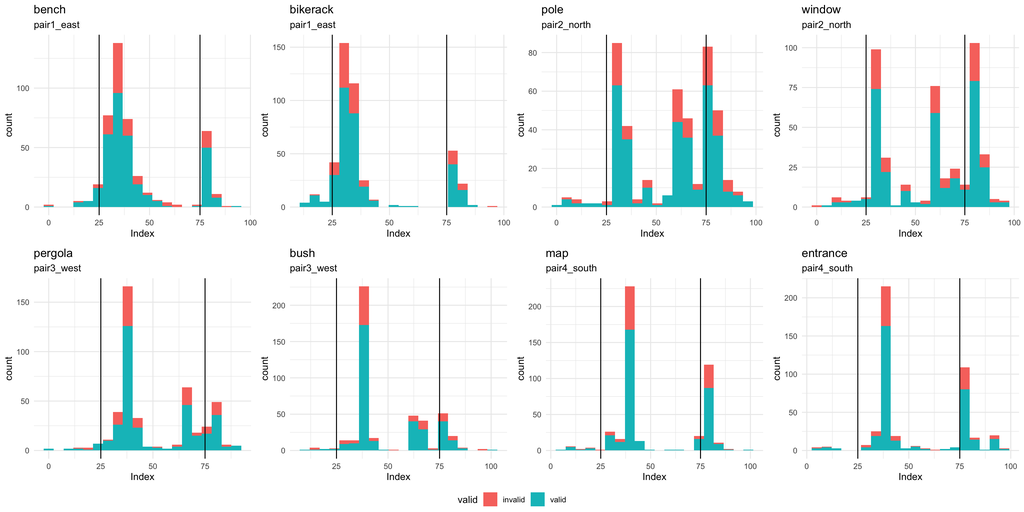

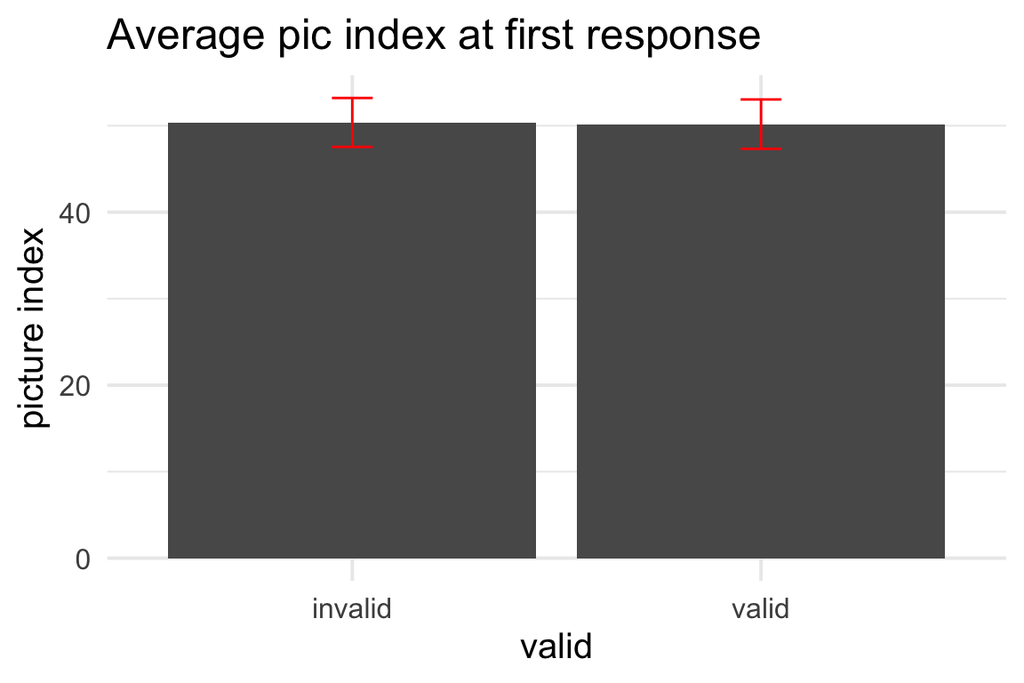

There doesn’t seem to be a significant difference between participant response in valid vs. invalid trials.

### Correct & Valid

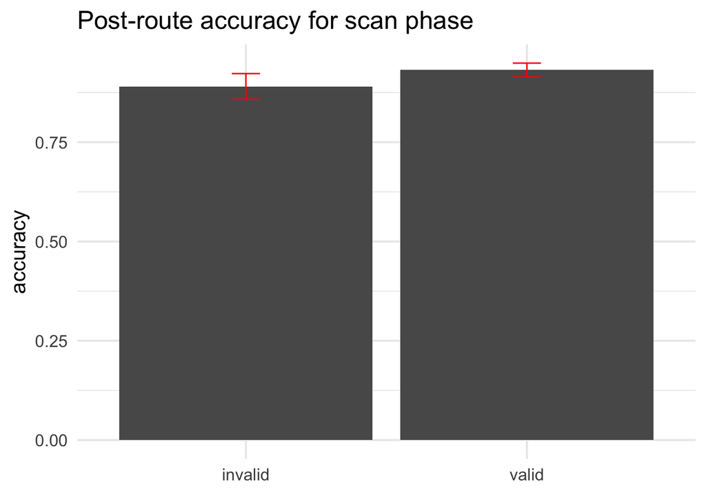

t-test for valid vs. invalid accuracy

```
##
##  Paired t-test
##
## data:  sub_plot %>% filter(valid == "valid") %>% .$m and sub_plot %>% filter(valid == "invalid") %>% .$m
## t = 1.7129, df = 37, p-value = 0.0951
## alternative hypothesis: true difference in means is not equal to 0
## 95 percent confidence interval:
##  -0.007561265  0.090248070
## sample estimates:
## mean of the differences
##               0.0413434
```

Separated by segment

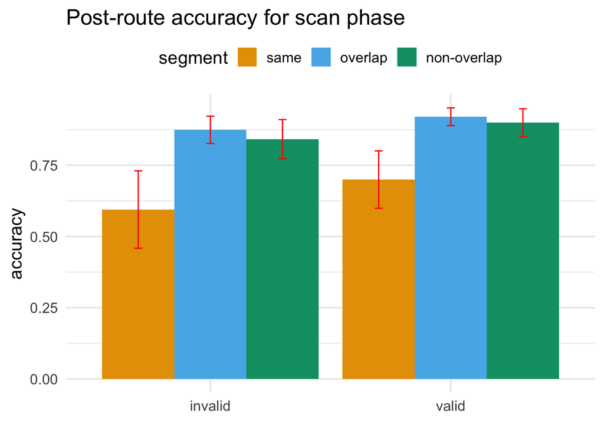

t-test for valid vs. invalid accuracy for the same segment (not paired due to imbalanced trials).

```
##
##  Paired t-test
##
## data:  pair_t_test_df$valid and pair_t_test_df$invalid
## t = 1.8933, df = 9, p-value = 0.09086
## alternative hypothesis: true difference in means is not equal to 0
## 95 percent confidence interval:
##  -0.04979884  0.56099542
## sample estimates:
## mean of the differences
##               0.2555983
```

```
##
##  Welch Two Sample t-test
##
## data:  sub_plot %>% filter(valid == "valid" & segment == "same") %>% .$m and sub_plot %>% filter(valid == "invalid" & segment == "same") %>% .$m
## t = 0.62177, df = 19.203, p-value = 0.5414
## alternative hypothesis: true difference in means is not equal to 0
## 95 percent confidence interval:
##  -0.2485983  0.4589324
## sample estimates:
## mean of x mean of y
## 0.6995726 0.5944056
```

```
##
##  One Sample t-test
##
## data:  sub_plot %>% filter(valid == "invalid" & segment == "same") %>% .$m
## t = 0.6952, df = 10, p-value = 0.5028
## alternative hypothesis: true mean is not equal to 0.5
## 95 percent confidence interval:
##  0.2918346 0.8969766
## sample estimates:
## mean of x
## 0.5944056
```

Percentage of correct for the question after seeing the whole route, separating by valid vs. invalid cue. Participants were instructed to indicate where they though they were going when pressing the button in the middle of the route. The answer for invalid is very slightly lower than valid.

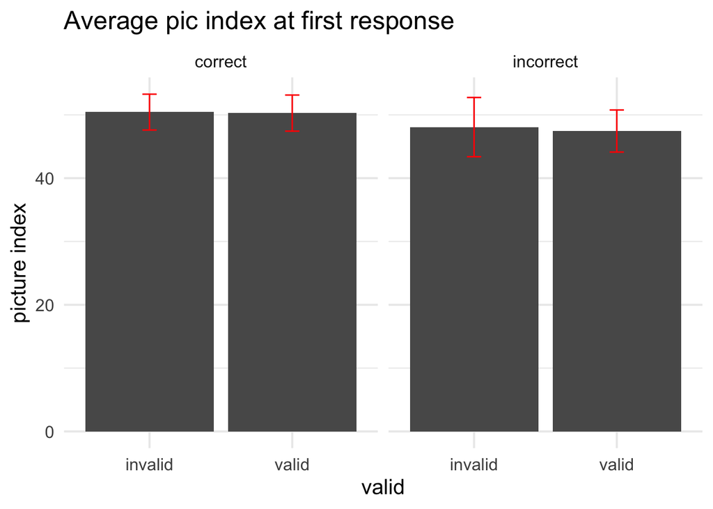

Separated by target, competitor, and non-competitor

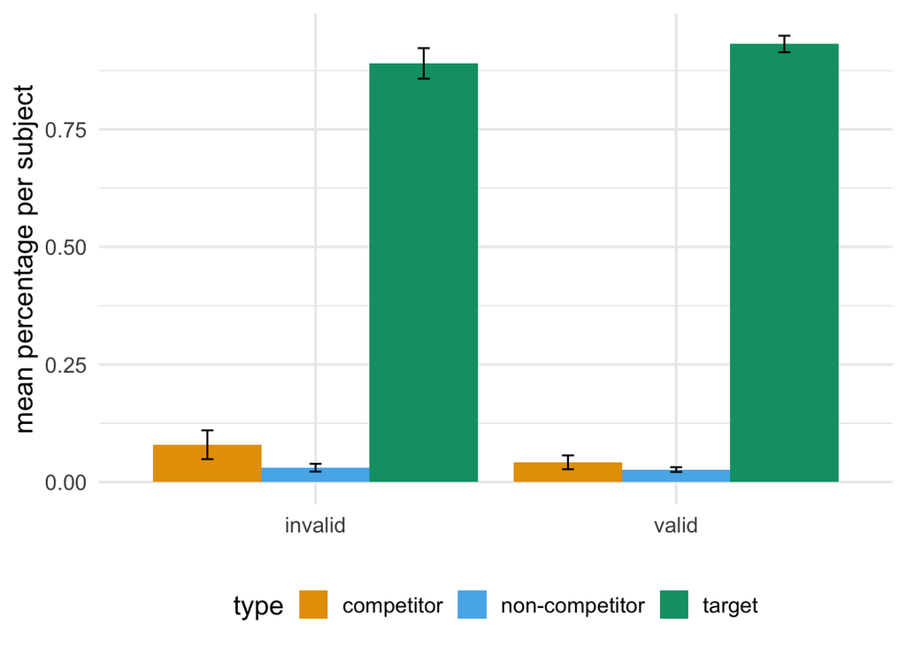

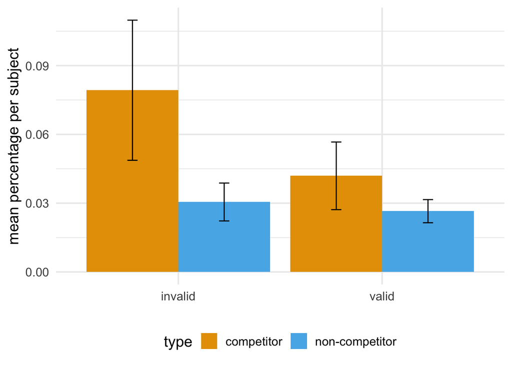

anova (3 type x 2 valid)

```
## $ANOVA
##       Effect DFn DFd             F            p p<.05          ges
## 2      valid   1  37 -1.710656e-14 1.000000e+00       2.130852e-32
## 3       type   2  74  5.048931e+02 7.390285e-44     * 9.122093e-01
## 4 valid:type   2  74  2.509259e+00 8.822772e-02       1.591959e-02
##
## $`Mauchly's Test for Sphericity`
##       Effect         W            p p<.05
## 3       type 0.1480853 1.172778e-15     *
## 4 valid:type 0.2665075 4.600131e-11     *
##
## $`Sphericity Corrections`
##       Effect       GGe        p[GG] p[GG]<.05       HFe        p[HF] p[HF]<.05
## 3       type 0.5399817 8.057354e-25         * 0.5434099 5.808895e-25         *
## 4 valid:type 0.5768701 1.164617e-01           0.5836331 1.159921e-01
```

For competitor, valid vs. invalid. Paired t-test.

```
##
##  Paired t-test
##
## data:  per_sub %>% filter(valid == "invalid" & type == "competitor") %>% .$percentage and per_sub %>% filter(valid == "valid" & type == "competitor") %>% .$percentage
## t = 1.5231, df = 37, p-value = 0.1362
## alternative hypothesis: true difference in means is not equal to 0
## 95 percent confidence interval:
##  -0.01233330  0.08700274
## sample estimates:
## mean of the differences
##              0.03733472
```